# Stack Exhange tags prediction

The goal of this [Kaggle](https://www.kaggle.com/c/transfer-learning-on-stack-exchange-tags) fun competition is to predict Stack Exchange tags based on Transfer Learning approach. In this competition, we provide the titles, text, and tags of Stack Exchange questions from six different site.

The challenge of this competition is to learn appropriate **physics** tags from others topic (travel, biology, cooking, robotic, crypto and tiy).

I will try to solve this problem using a classic text mining approach, I will try different Machine Learning approach. I will try also to use the [`sparklyr`](http://spark.rstudio.com/) library, It’s a R Apache Spark interface.

#### Libraries installation

```r
library(sparklyr)
library(dplyr)
library(ggplot2)
library(plotly)
library(stringr)
library(plotly)
library(tm)
library(wordcloud)
library(e1071) #Naive bayes classifier
library(stats)
library(factoextra) # PCA
```

#### LDA / supervised LDA / LDA arch / Analyse morophologique / Analyse syntaxique / embedding anglais (word2vec)

For memory issue (laptop with only 4Gb of RAM) I will analyze only first 1000 observations of each topic, it’s about only **~10%** of real data ! Kaggle provide also a test dataset with 81926 observations talking about physics. Each dataframe contains 4 colmuns (id, title, content and tags column for the train data).

```r
biology =  read.csv("../biology.csv",nrows =1000)
travel = read.csv("../travel.csv",nrows=1000)
robotic = read.csv("../robotics.csv",nrows=1000)
cooking = read.csv("../cooking.csv",nrows=1000)
crypto = read.csv("../crypto.csv",nrows=1000)
diy = read.csv("../diy.csv",nrows=1000)
test = read.csv("../test.csv",nrows=1000)
sample_submission = read.csv("../sample_submission.csv",nrows=1000)
```

#### Explore data

Lets explore the train dataset of multiple topics !

```r
travel[1:5,]
```

|  | id | title | content | tags |
| --- | --- | --- | --- | --- |
| 1 | 1 | What are some Caribbean cruises for October? | My fiancée and I are looking for a good Caribbean cruise in October and were wondering which islands are best to see and which Cruise line to take?\n\nIt seems like a lot of the cruises don't run in t… | caribbean cruising vacations |
| 2 | 2 | How can I find a guide that will take me safely through the Amazon jungle? | This was one of our definition questions, but also one that interests me personally: How can I find a guide that will take me safely through the Amazon jungle? I'd love to explore the Amazon but would… | guides extreme-tourism amazon-river amazon-jungle |
| 3 | 4 | Does Singapore Airlines offer any reward seats on their EWR-SIN route? | Singapore Airlines has an all-business class flight from EWR-SIN (Newark->Singapore), but I can't seem to find any reward Krisflyer flights for any dates. \n | loyalty-programs routes ewr singapore-airlines sin |
| 4 | 5 | What is the easiest transportation to use throughout Romania for a foreigner? | Another definition question that interested me was: What is the easiest transportation to use throughout Romania for a foreigner? I plan to visit at some point but I'm still relatively ignorant of how… | romania transportation |
| 5 | 6 | How can I visit Antarctica? | A year ago I was reading some magazine, and found out that there is availability to get a trip to Antarctica.\nUnfortunately, there was no info about how I could get there.\nDo you know anything about… | extreme-tourism antarctica |

As I said before, every train `dataframe` contains 4 colmuns, **id, title, content and tags**. The test `dataframe` contains only **id, title and content** colmun to be predicted is **tags**. Every observations contains many tags, So we should predict multiple tags of every document.

The test data that will be used to evaluate our model contains documents about **physics**, So we should predict physics tags from non physics topic. Lets show the 5 first document of test `dataframe` :

```r
test[1:5,]
```

|  | id | title | content |
| --- | --- | --- | --- |
| 1 | 1 | What is spin as it relates to subatomic particles? | I often hear about subatomic particles having a property called "spin" but also that it doesn't actually relate to spinning about an axis like you would think. Which particles have spin? What does spi… |
| 2 | 2 | What is your simplest explanation of the string theory? | How would you explain string theory to non physicists such as myself? I'm specially interested on how plausible is it and what is needed to successfully prove it?\n |
| 3 | 3 | Lie theory, Representations and particle physics | This is a question that has been posted at many different forums, I thought maybe someone here would have a better or more conceptual answer than I have seen before:\n\nWhy do physicists care about re… |
| 4 | 7 | Will Determinism be ever possible? | What are the main problems that we need to solve to prove Laplace's determinism correct and overcome the Uncertainty principle?\n |
| 5 | 9 | Hamilton's Principle | Hamilton's principle states that a dynamic system always follows a path such that its action integral is stationary (that is, maximum or minimum).\n\nWhy should the action integral be stationary? On w… |

#### Data exploration and visualization

##### Tags analysis

After showing the `dataframe`, I noticed that most of the time, the searched tag is contained in the title of the document. So we will start by analyzing documents titles and compare them with tags. Lets show the most frequent tags and comapre them to the most frequent word in the title corpus. We will count distinct tags frequency of every topic.

```r
countDistinctTags <- function(df,nFreq){
  df <- as.data.frame(as.factor(unlist(str_split(df$tags," "))))
  colnames(df) <- c("tags")
  df <- data.frame(table(df$tags))
  colnames(df) <- c("tags","Freq")
  df <- df[order(df$Freq,decreasing = TRUE),]
  df <- df[1:nFreq,]
  return(df)
}
```

```r
travel_tags <- countDistinctTags(travel,10)
biology_tags <- countDistinctTags(biology,10)
robotic_tags <- countDistinctTags(robotic,10)
cooking_tags <- countDistinctTags(cooking,10)
crypto_tags <- countDistinctTags(crypto,10)
diy_tags <- countDistinctTags(diy,10)
```

We can show the most frequent tags on every topic, lets plot a chart with differents topics

```r
travel_chart <- plot_ly(x = travel_tags$tags, y = travel_tags$Freq,type="bar",name="Travel tags")
biology_chart <- plot_ly(x = biology_tags$tags, y = biology_tags$Freq,type="bar",name="Biology tags")
robotic_chart <- plot_ly(x = robotic_tags$tags, y = robotic_tags$Freq,type="bar",name="Robotic tags")
cooking_chart <- plot_ly(x = cooking_tags$tags, y = cooking_tags$Freq,type="bar",name="Cooking tags")
crypto_chart <- plot_ly(x = crypto_tags$tags, y = crypto_tags$Freq,type="bar",name="Crypto tags")
diy_chart <- plot_ly(x = diy_tags$tags, y = diy_tags$Freq,type="bar",name="Diy tags")
subplot(travel_chart,biology_chart,robotic_chart,cooking_chart,crypto_chart,diy_chart,nrows = 3,margin = 0.12)
```

[interactive chart not shown]

##### Title analysis

```r
titleTagsProbability <- function(df){
  title_words <- sapply(str_split(df$title," "),'[',1:max(lengths(str_split(df$title," "))))
  title_words <- t(title_words[,1:ncol(title_words)])
  tag_words <- sapply(str_split(df$tags," "),'[',1:max(lengths(str_split(df$tags," "))))
  tag_words <- t(tag_words[,1:ncol(tag_words)])
  tag_in_title <- tag_words %in% title_words
  return(table(tag_in_title)["TRUE"] / length(tag_in_title))
}
```

We will focus now on documents title’s corpus of different topics to define the coorrelation between title and tags. `generateCorpus` generate a title corpus based from `df` title’s, We apply different pre-processing functions (remove punctuation, remove numbers, remove stop words …) to generate the corpus using `tm` package.

```r
generateCorpus <- function(df){
  corpus <- Corpus(VectorSource(df))
  corpus <- tm_map(corpus,removePunctuation)
  corpus <- tm_map(corpus,removeNumbers)
  corpus <- tm_map(corpus,tolower)
  corpus <- tm_map(corpus, removeWords, c("can", "get","best","good"))
  corpus <- tm_map(corpus,removeWords,stopwords("english"))
  corpus <- tm_map(corpus, stripWhitespace)
  corpus <- tm_map(corpus, PlainTextDocument)
  return(corpus)
}
```

Lets focus now on document title’s, we will generate the title corpus of **Travel** topic.

```r
travel_title_corpus <- generateCorpus(travel$title)
```

Now, lets generate the `document term matrix` associated to the travel titles corpus, and show the most frequent word in this corpus.

```r
dtm <- DocumentTermMatrix(travel_title_corpus)
dtm
```

```
<<DocumentTermMatrix (documents: 1000, terms: 2209)>>
Non-/sparse entries: 5361/2203639
Sparsity           : 100%
Maximal term length: 27
Weighting          : term frequency (tf)
```

```r
freq <- sort(colSums(as.matrix(dtm)),decreasing = TRUE)
wf <- data.frame(word=names(freq), freq=freq)[1:10,]
wf
```

|  | word | freq |
| --- | --- | --- |
| travel | travel | 84 |
| visa | visa | 66 |
| visit | visit | 40 |
| airport | airport | 39 |
| way | way | 34 |
| europe | europe | 32 |
| time | time | 30 |
| travelling | travelling | 29 |
| without | without | 29 |
| find | find | 28 |

We can see that the most frequent word in the title corpus is verry similar to the list of tags frequency defined before. Let’s plot a chart of word frequency and compare it to the previous tags frequency plot.

```r
p <- plot_ly(x = wf$word, y = wf$freq,type="bar",name="Travel title word")
subplot(travel_chart,p,nrows = 1)
```

[interactive chart not shown]

We can show the **word cloud** of title corpus and compare them to **tags** frequency.

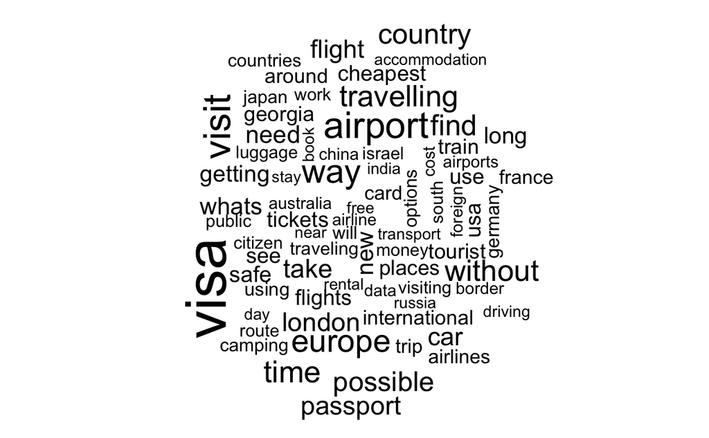

```r
wordcloud(names(freq),freq,min.freq = 10)
```

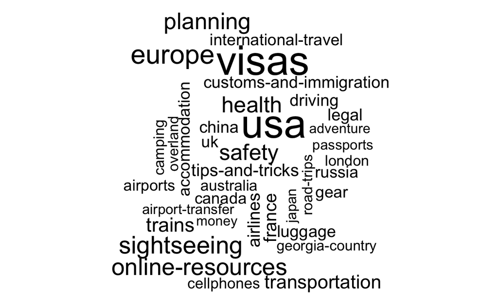

```r
wordcloud((countDistinctTags(travel,40))$tags,(countDistinctTags(travel,40))$Freq)
```

##### TODO : Apply Latent Dirichlet allocation

##### Generate TfIdf matrix

We will now generate the **tfidf** matrix to reflect how important a word is to a document in the corpus. The **tfidf** is defined as the product of two statistics, term frequency and inverse document frequency.

$tf(t,d) = 0.5 + 0.5 \cdot\left(\frac{\underset{t,d}f}{max \{ \underset{t\prime,d}f \::\: t\prime \in d \}}\right)$

$idf(t,D) = log \left(\frac{N}{|\{ d \in D \:: \:t \in d\}|} \right)$

$tfidf(t,d,D) = tf(t,d)\cdot idf(t,D)$

We will start by generate only the **tfidf** matrix of title corpus defined before (because of memory issues ! )

```r
tfidf <- DocumentTermMatrix(travel_title_corpus, control = list(weighting = weightTfIdf))
tfidf
```

```
<<DocumentTermMatrix (documents: 1000, terms: 2209)>>
Non-/sparse entries: 5361/2203639
Sparsity           : 100%
Maximal term length: 27
Weighting          : term frequency - inverse document frequency (normalized) (tf-idf)
```

##### Dimensionality reduction with PCA

The **tfidf** matrix generated based on only 1000 titles of travel documents contains 2209 distinct words, so we have 2209 dimensions, in this case its necessary to the a dimensionality reduction to reduce dimensions. In this case we will use the **Principal component analysis (PCA)**, it’s a mathematical procedure that transforms a number of correlated variables into a smaller number of uncorrelated variables called **principale components**. The first principal component accounts for as much of the variability in the data as possible, and each succeeding component accounts for as much of the remaining variability as possible.

```r
tfidf.pca <- prcomp(tfidf,scale. = TRUE)
```

Let’s study variances of the principale components, we will start by calculate the **Eigenvalues** that measure the variability retained by each PC. It’s large for the first PC and small for the subsequent PCs, we will also calculate the **variance** and the **cumulative variances** of each PC.

[output not shown]

[output cut: 990 more lines]

Let show the importance of the first 50 principal components (PC) using a simple barplot.

```r
eig.dataframe <- eig.dataframe[1:50,]
plot_ly(x = nrow(eig.dataframe):1, y = eig.dataframe$cumvariance,type="bar",name="PCs importance") %>% layout(yaxis = list(title = 'Cumulative variance'),xaxis = list(title = "Principal components")) %>% add_trace(x=nrow(eig.dataframe):1,y=eig.dataframe$cumvariance,mode = "lines",name="PC importance")
```

[interactive chart not shown]

```r
sum(eig.dataframe$variance)
```

```
[1] 11.52325
```

We can see that the first 50 PCs contains only **11.52 %** of total variance, we lose **88.48 %** of data informations, so we can’t take only the first 50 PCs.